# Лабораторная работа №8

Адресация IPv4 и IPv6. Настройка маршрутизации

Чилеше Лупупа

Российский университет дружбы народов, Москва, Россия

2025

# Цели и задачи работы

## Цель лабораторной работы

Изучение принципов маршрутизации в IPv4- и IPv6-сетях  
и практическая настройка сетевого оборудования в среде GNS3.

## Задачи

- Смоделировать сеть на базе VyOS и коммутаторов в GNS3
- Настроить IPv6-адресацию оконечных узлов и RA на маршрутизаторах
- Проверить связность до и после настройки динамической IPv4-маршрутизации (RIP)
- Создать туннель IPv6 over IPv4 (SIT) и настроить статическую маршрутизацию IPv6
- Подтвердить работу сети проверками ping/trace и анализом трафика в Wireshark

# Выполнение работы

## Топология сети

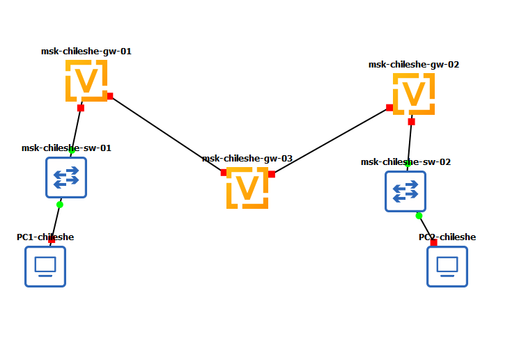

Топология сети с тремя маршрутизаторами

## Адресация (логика сегментов)

- LAN1 (IPv6): 1000::/64 (PC1 — 1000::a/64, GW — 1000::1/64)
- LAN2 (IPv6): 1002::/64 (PC2 — 1002::a/64, GW — 1002::1/64)
- Транзит IPv4: 10.0.0.0/8 (между gw-01 и gw-03)
- Транзит IPv4: 20.0.0.0/8 (между gw-03 и gw-02)

## Настройка PC1 (IPv6)

[figure not shown]

Настройка IPv6 на PC1

- Назначен адрес 1000::a/64
- Конфигурация сохранена в startup.vpc

## Настройка PC2 (IPv6)

[figure not shown]

Настройка IPv6 на PC2

- Назначен адрес 1002::a/64
- Конфигурация сохранена в startup.vpc

## Идентификация маршрутизатора

[figure not shown]

Изменение имени маршрутизатора msk-chileshe-gw-01

- Задано имя устройства по шаблону msk-chileshe-gw-0x
- Конфигурация применена и сохранена

## Интерфейсы и RA на gw-01

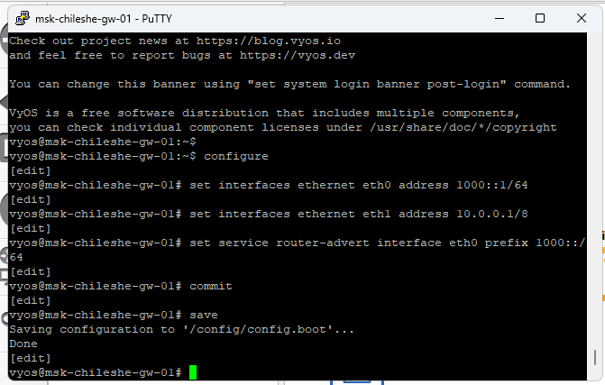

Настройка интерфейсов msk-chileshe-gw-01

- eth0: 1000::1/64 + Router Advertisement (префикс 1000::/64)
- eth1: 10.0.0.1/8

## Интерфейсы и RA на gw-02

[figure not shown]

Настройка интерфейсов msk-chileshe-gw-02

- eth0: 1002::1/64 + Router Advertisement (префикс 1002::/64)
- eth1: 20.0.0.2/8

## Транзитные интерфейсы gw-03

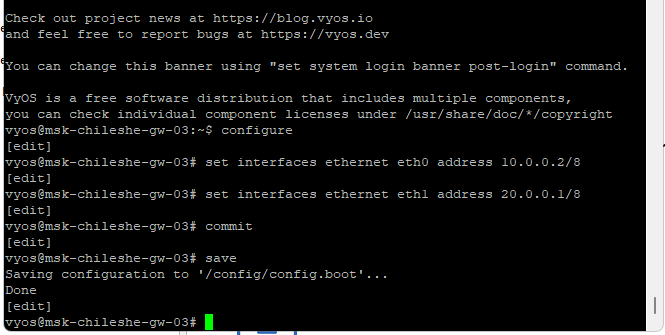

Настройка интерфейсов msk-chileshe-gw-03

- eth0: 10.0.0.2/8
- eth1: 20.0.0.1/8

## Проверка на PC1

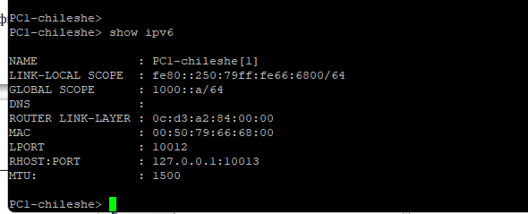

Проверка IPv6 на PC1

- Появился ROUTER LINK-LAYER (MAC ближайшего маршрутизатора)
- Это подтверждает работу RA и NDP в сегменте 1000::/64

## Проверка на PC2

[figure not shown]

Проверка IPv6 на PC2

- Аналогично зафиксирован ближайший маршрутизатор в сегменте 1002::/64
- RA корректно распространяет параметры сети

## Проверка связности с gw-01

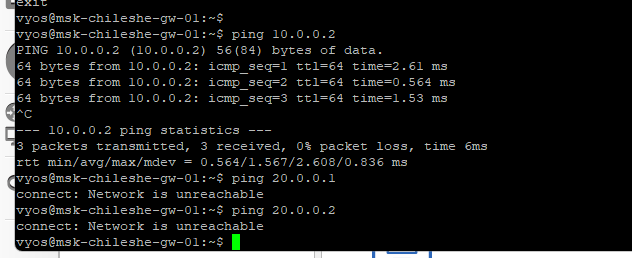

Проверка связности до настройки RIP

Наблюдения: - 10.0.0.2 доступен (непосредственно подключённая сеть 10.0.0.0/8)  
- 20.0.0.1 и 20.0.0.2 недоступны (Network is unreachable)  
Причина: отсутствует маршрут к 20.0.0.0/8

## Анализ трафика до RIP

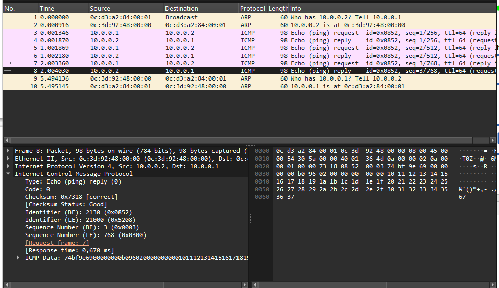

Анализ ICMP-трафика до настройки RIP

- Видны ICMP Echo Request/Reply между 10.0.0.1 и 10.0.0.2
- Пакеты к 20.0.0.0/8 не формируются из-за отсутствия маршрута

## RIP на gw-01

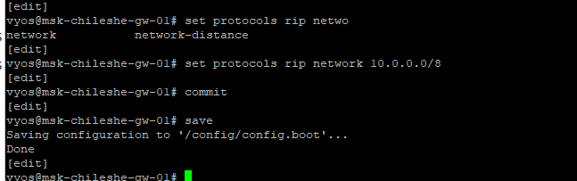

Настройка RIP на msk-chileshe-gw-01

- Анонсируется сеть 10.0.0.0/8

## RIP на gw-02

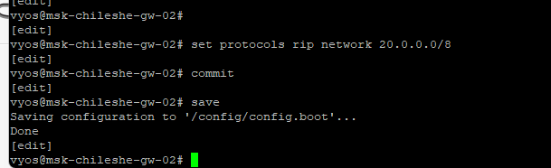

Настройка RIP на msk-chileshe-gw-02

- Анонсируется сеть 20.0.0.0/8

## RIP на gw-03

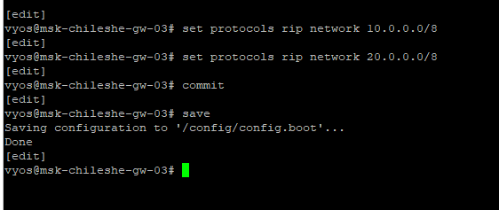

Настройка RIP на msk-chileshe-gw-03

- Анонсируются сети 10.0.0.0/8 и 20.0.0.0/8
- gw-03 играет роль транзитного маршрутизатора между доменами

## Повторная проверка связности с gw-01

[figure not shown]

Проверка связности после настройки RIP

Результат: - Все адреса (10.0.0.2, 20.0.0.1, 20.0.0.2) стали доступны  
- Потери отсутствуют  
Причина: RIP распространил информацию о маршрутах к удалённым сетям

## Трафик RIP и ICMP в Wireshark

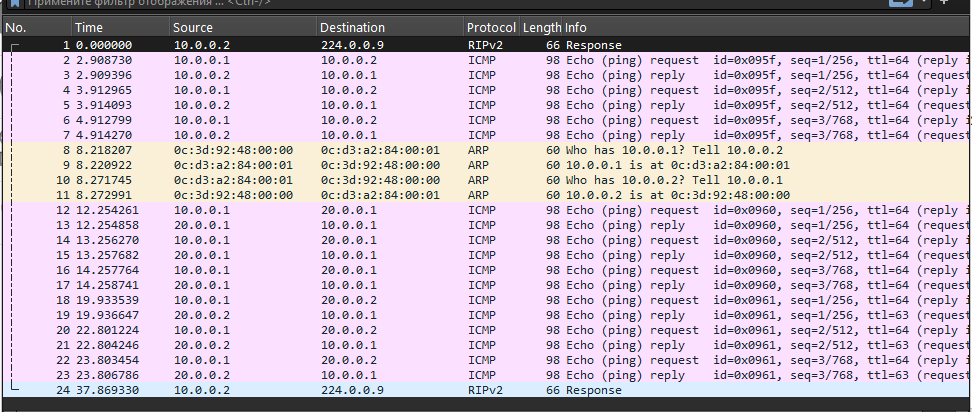

Анализ RIP и ICMP-трафика

- RIP передаётся на 224.0.0.9 (RIPv2)
- На фоне обновлений RIP видны ICMP-пакеты, проходящие через транзит

## Создание туннеля на gw-01

[figure not shown]

Настройка туннеля на msk-chileshe-gw-01

- tun0: SIT, source 10.0.0.1, remote 20.0.0.2
- IPv6-адрес туннеля: 1001::1/64

## Создание туннеля на gw-02

[figure not shown]

Настройка туннеля на msk-chileshe-gw-02

- tun0: SIT, source 20.0.0.2, remote 10.0.0.1
- IPv6-адрес туннеля: 1001::2/64

## Route6 на gw-01

[figure not shown]

Статический маршрут IPv6 на msk-chileshe-gw-01

- Маршрут к 1002::/64 через next-hop 1001::2 (туннель)

## Route6 на gw-02

[figure not shown]

Статический маршрут IPv6 на msk-chileshe-gw-02

- Маршрут к 1000::/64 через next-hop 1001::1 (туннель)

## PC1 → PC2 (ping и trace)

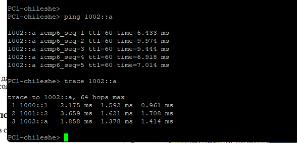

Ping и trace с PC1

- Успешные ответы ICMPv6
- Trace фиксирует прохождение через 1000::1 и туннельный next-hop 1001::2

## PC2 → PC1 (ping и trace)

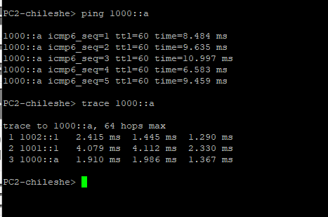

Ping и trace с PC2

- Успешные ответы ICMPv6
- Маршрут симметричен: 1002::1 → 1001::1 → 1000::a

## Инкапсуляция IPv6 в IPv4

[figure not shown]

Инкапсуляция IPv6 в IPv4 в Wireshark

Где видна информация о прохождении по туннелю: - Во внешнем IPv4-заголовке: Source/Destination = 20.0.0.2 ↔︎ 10.0.0.1  
- В поле протокола внешнего IPv4: Protocol = 41 (IPv6)  
- Внутри — исходный IPv6-пакет (адреса 1002::a ↔︎ 1000::a) и ICMPv6

# Вывод

## Вывод

- Смоделирована сеть в GNS3 на базе VyOS и VPCS
- Настроены IPv6-адреса и Router Advertisement в локальных сегментах
- Динамическая IPv4-маршрутизация RIP обеспечила связность между 10.0.0.0/8 и 20.0.0.0/8
- Реализован туннель IPv6 over IPv4 (SIT) и статическая маршрутизация IPv6
- Доступность подтверждена ping/trace; инкапсуляция подтверждена анализом Wireshark